# lab1content

```python
import numpy as np
import matplotlib
import matplotlib.pyplot as plt
import scipy
from scipy import stats
from scipy.stats import binom
```

a little statistics problem1

```python
x = np.linspace(2,3,5)
y = stats.norm.cdf(x)
y
```

```
array([0.97724987, 0.98777553, 0.99379033, 0.99702024, 0.9986501 ])
```

```python
stats.norm.ppf(y)
```

```
array([2.  , 2.25, 2.5 , 2.75, 3.  ])
```

If the negative values appear, it means that smaller than the mean of the normal distribution. It is on the left of the symmetry.

problem2, choosing the exponential distribution

```python
z = stats.expon.rvs(loc = 5., scale = 0.01, size = 100000)
z
```

```
array([5.00189901, 5.00178945, 5.01336512, ..., 5.00066623, 5.01088031,
       5.00175814])
```

make plots

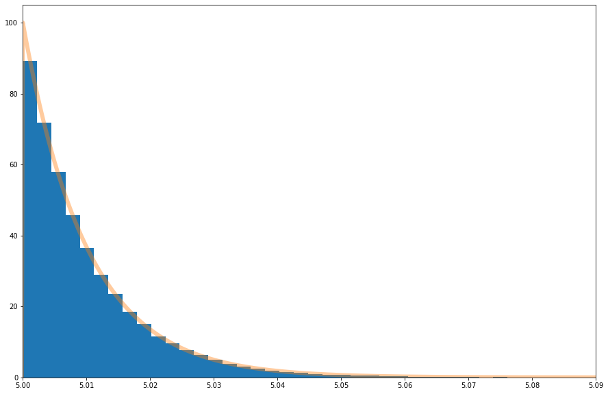

```python
plt.rcParams["figure.figsize"] = (15,10)
fig, ax = plt.subplots(1, 1)
ax.hist(z,50, density=True)
plt.tick_params(labelsize = 10)
plt.xlim([5.00,5.09])
x = np.linspace(4.95,5.1,1000)
ax.plot(x,stats.expon.pdf(x,loc = 5, scale = 0.01),linewidth = 6,alpha = 0.4)
plt.show()
```

problem 3, the signal-free data follows the exponential distribution

a. select the hypothetical measurement value be 5.015 b. the problem is that what is the probability that value measured less than 5.015 c. the intergal is the pdf over the interval (-oo, 5.015)

```python
val = 5.015
pro = stats.expon.cdf(val, loc = 5, scale = 0.01)
pro
```

```
0.776869839851563
```

The answer to the part b) is 0.7769.

```python
a = stats.expon.ppf(pro,loc = 5, scale = 0.01)
a
```

```
5.015
```

the value of a is same as the hypothetical value we have chosen

```python
#using the sigma formula
meanValue = np.mean(z)
sig = (val - meanValue)/0.01
sig
```

```
0.49979322160149664
```

The sigma value is about 0.5.

problem 4

trial 1

```python
val2 = 5.008
pro2 = stats.expon.cdf(val2, loc = 5, scale = 0.01)
pro2
```

```
0.5506710358827787
```

```python
sig2 = (val2 - meanValue)/0.01
sig2
```

```
-0.20020677839847068
```

```python
val3 = 5.08
pro3 = stats.expon.cdf(val3, loc = 5, scale = 0.01)
pro3
```

```
0.9996645373720975
```

```python
sig3 = (val3 - meanValue)/0.01
sig3
```

```
6.999793221601536
```

The pattern is that with the increasing of x values, then the probability always keeps increasing. Because we always measure the area on the left of the chosen value, then the area keeps increasing. Meanwhile, the sigma will change from the negative value to the positive value, and its absolute value is initially decrease then to zero then finally increase.

part 2 non-continous distributions, choosing the Binomial

The parameters are n and p, where p is the probability of success of one single trial, and n is the total number of trials.

trial one, n is 50 and p = 0.7

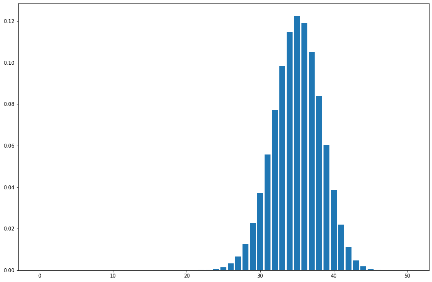

```python
n = 50
p = 0.7
values = np.linspace(0,n,n+1)
dist = [binom.pmf(b, n, p) for b in values ]
plt.bar(values, dist)
plt.show()
```

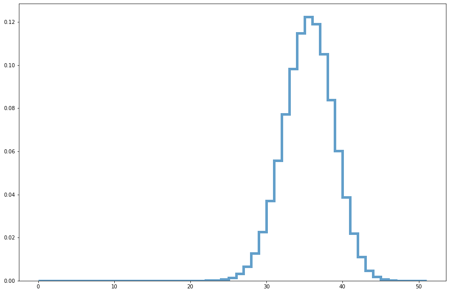

```python
plt.stairs(dist,linewidth = 5,alpha = 0.7)
plt.show()
```

trial two, with p = 0.35 and n =100

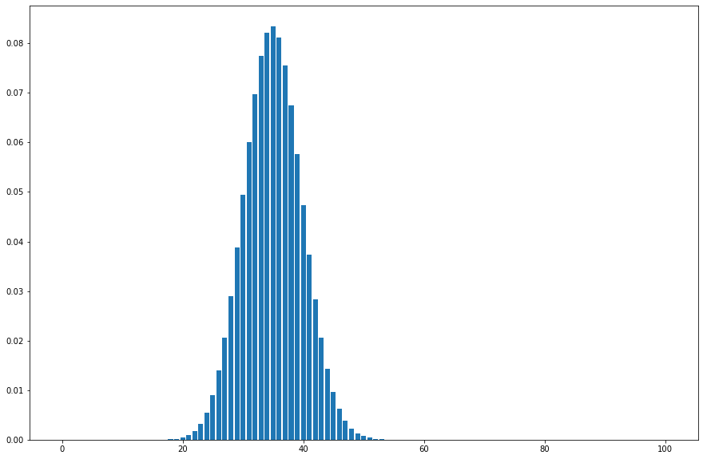

```python
n2 = 100
p2 = 0.35
values2 = np.linspace(0,n2,n2+1)
dist2 = [binom.pmf(b2, n2, p2) for b2 in values2 ]
plt.bar(values2, dist2)
plt.show()
```

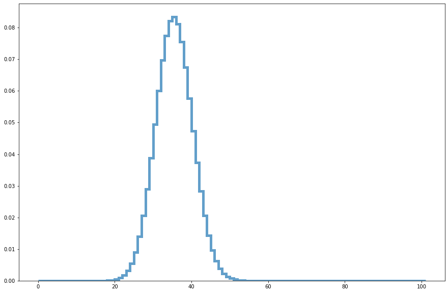

```python
plt.stairs(dist2,linewidth = 5,alpha = 0.7)
plt.show()
```

The explanation to the features is that both two parameters are so important and control the pattern, the mean is always np, and it is exactly at the line of symmetry. Meanwhile, when n is larger, then the plot will be much wider.

The question is that what is the probability of having 30 events over total 100 trials if the probability of success is 0.35

```python
ans = binom.pmf(30, 100, 0.35)
ans
```

```
0.049421376758863836
```

When the probability of one single success is 0.35, then the probability of having 30 events over total 100 trials will be 0.049.

In my opinion, I believe the parameters in one model can always be both continous and discrete. This characteristics are related with themselves, just related to the defination and the way you want to count them. Meanwhile, there are always some characteristic number used to describe the data distribution, like the probability and sigma, this kind of data should be in accordance with the data distribution itself, all continous or all discrete.